# Chapter 2

# Libraries

```r
library(psych)
library(ggplot2)
library(reshape2)
library(magrittr)
library(tidyr)
library(purrr)
library(dplyr)
```

# Customer Expenses Data

A survey of 24 customers on their percentages of expenditure on 9 major categories is conducted: Food X1, Transport X2, Living X3, Communication X4, Entertainment X5, Other X6, Clothing X7, Education X8 and Saving X9.

## EDA

```r
exp_eg <- read.csv("/Users/jasonchan/MSTAT/STAT8019_Marketing_Analytics/data/exp_eg.csv")

head(exp_eg)
```

|  | food | transpor | living | commun | entertai | other | cloth | educatio | saving | shop | case |
| --- | --- | --- | --- | --- | --- | --- | --- | --- | --- | --- | --- |
| 1 | 3.3 | 0.9 | 27.6 | 0.9 | 8.2 | 19.1 | 6.2 | 26.6 | 7.2 | 1 | c1 |
| 2 | 9.2 | 0.1 | 21.8 | 0.6 | 8.3 | 14.6 | 6.5 | 32.2 | 7.1 | 1 | c2 |
| 3 | 10.8 | 0.8 | 27.5 | 0.9 | 8.9 | 16.8 | 6.0 | 22.6 | 5.7 | 1 | c3 |
| 4 | 6.7 | 1.3 | 35.8 | 0.9 | 7.3 | 14.4 | 5.0 | 22.3 | 6.1 | 1 | c4 |
| 5 | 23.2 | 1.0 | 20.7 | 1.3 | 7.5 | 16.8 | 2.8 | 20.8 | 6.1 | 1 | c5 |
| 6 | 15.9 | 0.6 | 27.6 | 0.5 | 10.0 | 18.1 | 1.6 | 20.1 | 5.7 | 1 | c6 |

```r
describe(exp_eg[1:9], skew=FALSE, ranges=FALSE)
```

|  | vars | n | mean | sd | se |
| --- | --- | --- | --- | --- | --- |
| food | 1 | 24 | 15.91 | 10.73 | 2.19 |
| transpor | 2 | 24 | 1.27 | 1.00 | 0.20 |
| living | 3 | 24 | 28.23 | 5.61 | 1.14 |
| commun | 4 | 24 | 0.93 | 0.35 | 0.07 |
| entertai | 5 | 24 | 8.53 | 1.05 | 0.21 |
| other | 6 | 24 | 13.55 | 4.23 | 0.86 |
| cloth | 7 | 24 | 3.82 | 2.42 | 0.49 |
| educatio | 8 | 24 | 20.98 | 6.12 | 1.25 |
| saving | 9 | 24 | 6.79 | 1.13 | 0.23 |

### Scatterplot Matrix

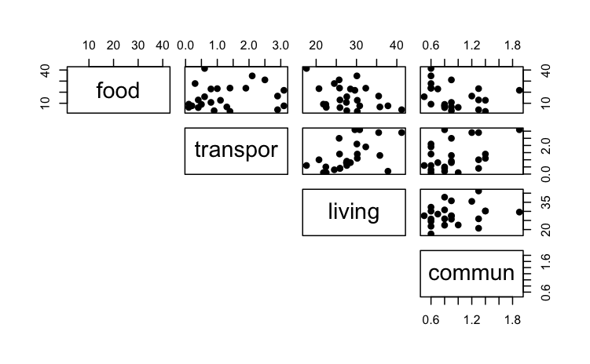

```r
pairs(exp_eg[1:4], pch = 19, lower.panel = NULL)
```

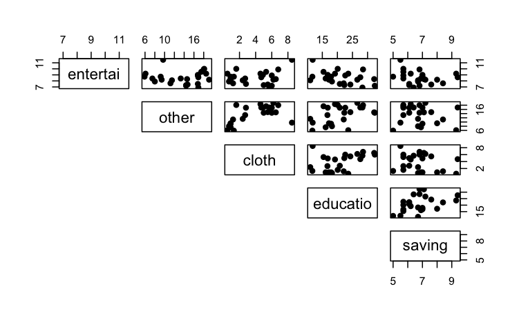

```r
pairs(exp_eg[5:9], pch = 19, lower.panel = NULL)
```

## Distribution Plots

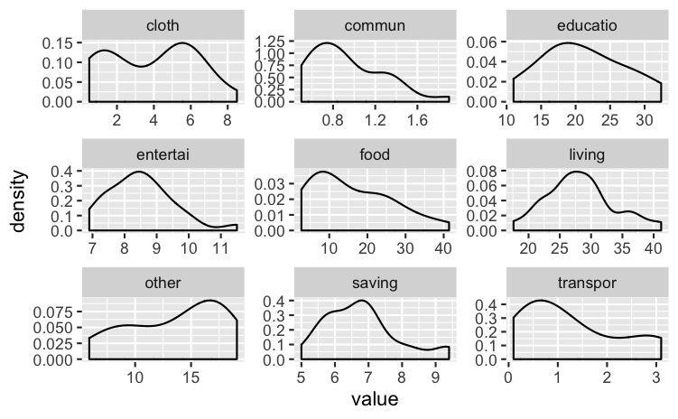

```r
exp_eg[1:9] %>%
  keep(is.numeric) %>%                     # Keep only numeric columns
  gather() %>%                             # Convert to key-value pairs
  ggplot(aes(value)) +                     # Plot the values
    facet_wrap(~ key, scales = "free") +   # In separate panels
    geom_density()
```

## Hierarchical Clustering

### Standard Scaling

```r
exp <- scale(exp_eg[, 1:9])
head(round(exp, 3))
```

```
       food transpor living commun entertai other  cloth
[1,] -1.176   -0.365 -0.112 -0.095   -0.311 1.311  0.986
[2,] -0.626   -1.163 -1.147 -0.950   -0.215 0.247  1.110
[3,] -0.477   -0.465 -0.130 -0.095    0.359 0.767  0.903
[4,] -0.859    0.033  1.351 -0.095   -1.172 0.200  0.489
[5,]  0.679   -0.266 -1.343  1.045   -0.980 0.767 -0.421
[6,] -0.001   -0.664 -0.112 -1.235    1.411 1.075 -0.917
     educatio saving
[1,]    0.919  0.362
[2,]    1.834  0.273
[3,]    0.266 -0.968
[4,]    0.216 -0.613
[5,]   -0.029 -0.613
[6,]   -0.143 -0.968
```

### Proximity Matrix (Squared Euclidean Distance)

```r
dist<-dist(exp,method="euclidean")^2
round(dist, 2)
```

```
       1     2     3     4     5     6     7     8     9    10
2   4.74
3   3.44  6.92
4   6.07 13.16  5.55
5  10.84 13.98  7.90 12.26
6  12.30 14.67  6.25 14.33 13.53
7   9.00 19.22  6.85  8.64 15.18 10.20
8   4.62  4.83  4.52 16.02 14.17 11.38 15.36
9   4.94 12.48  8.12  4.79 10.11 22.87 13.45 13.61
10  6.82 16.04  4.82  7.79  7.80 11.62  7.99  9.66  8.92
11  4.47  7.50  6.84  7.50  5.72 18.14 16.42  9.17  4.65  5.59
12 29.02 25.39 20.78 28.13 12.09 17.76 28.61 29.84 36.77 22.00
13  6.01  6.15 12.82 17.69 15.64 17.79 19.38  8.25 15.91 13.13
14 15.01 13.81  7.48 12.70  7.11  5.85 15.96 16.32 21.20 12.02
15 27.62 28.14 14.84 27.24 30.36 16.83 21.13 20.22 39.47 18.25
16  3.67  2.26  6.99  7.30 11.92 17.94 17.90  8.69  5.63 14.40
17 10.99 19.61  5.72  7.80 19.72  7.97 10.72 13.88 17.47  7.45
18 20.23 22.22 15.44 10.47 14.76 13.73 14.56 28.63 21.79 15.58
19 20.77 29.76 17.06 11.44 17.05 18.73 10.67 29.03 18.50 10.64
20 20.93 33.91 25.01 12.11 26.50 31.32 16.94 35.58 16.08 15.96
21 28.92 39.48 27.44 23.06 17.15 34.20 22.11 36.45 21.98 13.89
22 24.75 26.25 18.33 18.02 12.16 17.27 16.36 29.76 25.99 15.48
23 34.73 35.50 21.60 21.34 20.64 17.73 21.26 38.87 36.51 23.17
24 24.32 20.73 24.49 25.14 23.17 20.70 25.75 26.66 32.82 22.09
      11    12    13    14    15    16    17    18    19    20
2
3
4
5
6
7
8
9
10
11
12 21.24
13  7.10 26.04
14 12.70  5.14 18.95
15 30.10 25.15 34.71 16.99
16  4.78 29.05  8.83 15.27 34.78
```

[output cut: 17 more lines]

```
10
11
12
13
14
15
16
17
18
19
20
21
22 10.95
23 25.01  5.22
24 21.06  9.16 20.77
```

### Linkage

#### Single Linkage

```r
fit <- hclust(dist, method="single")

#clustering histroy, height is distance
history<-cbind(fit$merge,fit$height)
history
```

```
      [,1] [,2]      [,3]
 [1,]   -2  -16  2.256218
 [2,]  -18  -22  3.362055
 [3,]   -1   -3  3.444286
 [4,]    1    3  3.669275
 [5,]  -11    4  4.474659
 [6,]   -8    5  4.524085
 [7,]   -9    6  4.649171
 [8,]   -4    7  4.787711
 [9,]  -10    8  4.824054
[10,]  -12  -14  5.143519
[11,]  -23    2  5.223810
[12,]  -19   11  5.425475
[13,]   -5    9  5.719780
[14,]  -17   13  5.723455
[15,]  -20   12  5.786127
[16,]   -6   10  5.851593
[17,]  -13   14  6.013709
[18,]   16   17  6.245700
[19,]  -21   15  6.389848
[20,]   -7   18  6.850450
[21,]   19   20  7.961211
[22,]  -24   21  9.157467
[23,]  -15   22 14.387215
```

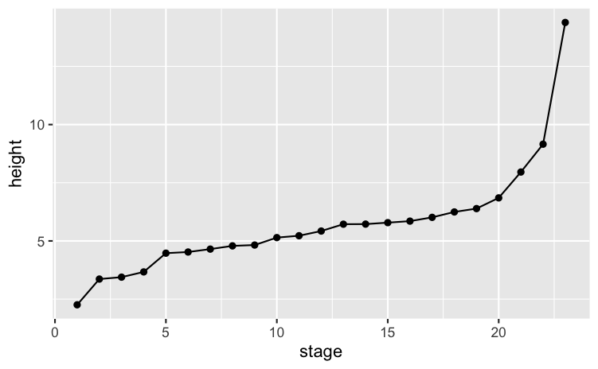

```r
#distance plot
ggplot(mapping=aes(x=1:length(fit$height),y=fit$height))+
  geom_line()+
  geom_point()+
  labs(x="stage",y="height")

#dendrogram
par(mar=c(1,4,1,1))
```

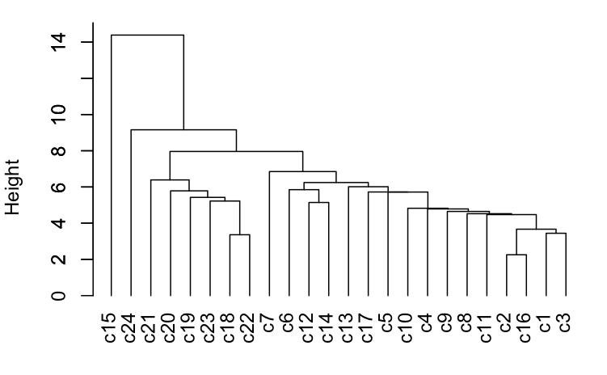

```r
plot(fit,labels=exp_eg$case,hang=-1,main="")
axis(side = 2, at = seq(0, 16, 2))
```

```r
#4-cluster solution
cutree(fit, k=4) #cluster index
```

```
 [1] 1 1 1 1 1 1 1 1 1 1 1 1 1 1 2 1 1 3 3 3 3 3 3 4
```

```r
sol <- data.frame(cluster=cutree(fit, k=4),id=exp_eg$case)
sol
```

| cluster | id |
| --- | --- |
| 1 | c1 |
| 1 | c2 |
| 1 | c3 |
| 1 | c4 |
| 1 | c5 |
| 1 | c6 |
| 1 | c7 |
| 1 | c8 |
| 1 | c9 |
| 1 | c10 |

[output cut: 14 more lines]

#### Ward’s method

```r
#Ward's method
#dist<-dist(exp,method="euclidean")^2
fit <- hclust(dist, method="ward.D")
history<-cbind(fit$merge,fit$height)
history
```

```
      [,1] [,2]       [,3]
 [1,]   -2  -16   2.256218
 [2,]  -18  -22   3.362055
 [3,]   -1   -3   3.444286
 [4,]   -9  -11   4.649171
 [5,]   -8    3   4.946464
 [6,]  -12  -14   5.143519
 [7,]  -19  -20   5.786127
 [8,]  -23    2   6.065803
 [9,]   -4    4   6.641508
[10,]  -10  -17   7.446012
[11,]  -13    1   9.233208
[12,]  -21    7   9.796727
[13,]   -7   10   9.992928
[14,]   -6   13  10.533612
[15,]    5   11  11.032532
[16,]   -5    6  11.087441
[17,]  -24    8  17.326237
[18,]    9   15  19.128192
[19,]  -15   14  22.644700
[20,]   16   17  27.304278
[21,]   18   19  51.236687
[22,]   12   20  55.865952
[23,]   21   22 109.076343
```

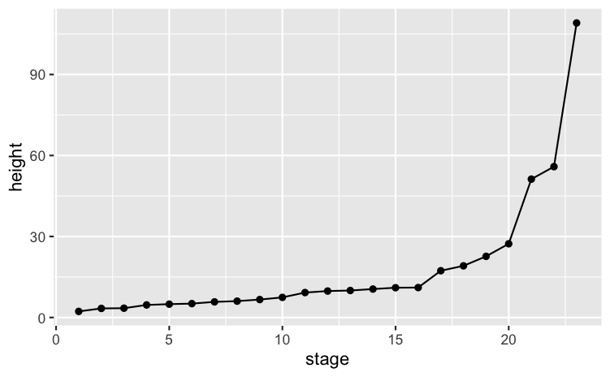

```r
ggplot(mapping=aes(x=1:length(fit$height),y=fit$height))+
  geom_line()+
  geom_point()+
  labs(x="stage",y="height")
```

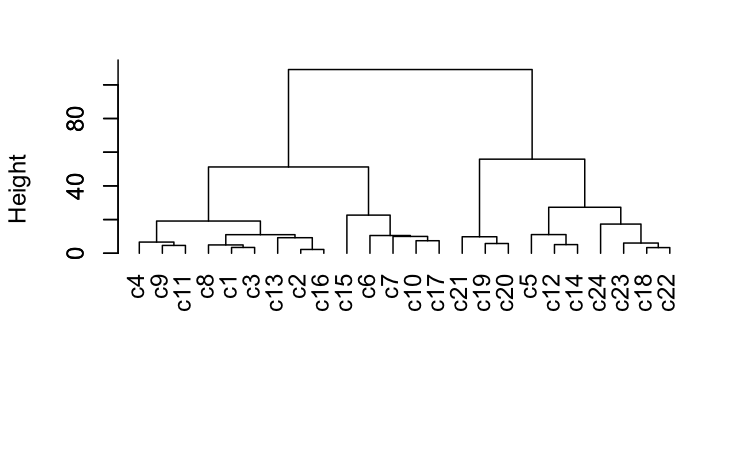

```r
plot(fit,labels=exp_eg$case,hang=-1,sub="",xlab="",main="")
axis(side = 2, at = seq(0, 100, 20))
```

```r
#clustering
cluster<-cutree(fit,k=4)
case<-exp_eg$case
sol <- data.frame(cluster,exp,case)
sol[ order(sol$cluster),c(1,11) ]
```

|  | cluster | case |
| --- | --- | --- |
| 1 | 1 | c1 |
| 2 | 1 | c2 |
| 3 | 1 | c3 |
| 4 | 1 | c4 |
| 8 | 1 | c8 |
| 9 | 1 | c9 |
| 11 | 1 | c11 |
| 13 | 1 | c13 |
| 16 | 1 | c16 |
| 5 | 2 | c5 |

[output cut: 14 more lines]

## Profile Plots

Get centroids (means) fo each variable and compare across clusters

```r
#cluster means
tb<-aggregate(x=sol[,2:10], by=list(cluster=sol$cluster),FUN=mean)
print(tb,digits=2)
```

| cluster | food | transpor | living | commun | entertai | other | cloth | educatio | saving |
| --- | --- | --- | --- | --- | --- | --- | --- | --- | --- |
| 1 | -0.7882974 | -0.6090842 | -0.2866902 | 0.06331441 | -0.4277219 | 0.6254447 | 0.8296166 | 1.0170897 | 0.1944981 |
| 2 | 1.2532158 | 0.1328911 | -0.5327787 | -0.54269495 | -0.2015265 | -0.8705572 | -0.9110353 | -0.6704739 | -0.1445546 |
| 3 | -0.2360620 | -0.1063129 | 0.4907681 | -0.26592052 | 1.2576617 | 0.6065336 | 0.4812236 | -0.7050188 | -0.6839439 |
| 4 | -0.1658415 | 1.6943615 | 1.2852743 | 1.51954586 | -0.3427088 | -0.8559236 | -1.1651402 | -0.3117986 | 0.8937064 |

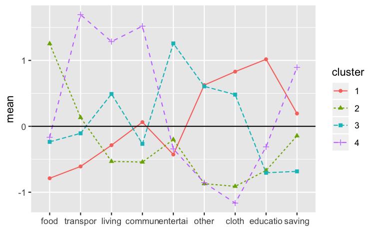

```r
#profile plot
tbm<-melt(tb,id.vars='cluster')
tbm$cluster<-factor(tbm$cluster)
ggplot(tbm,
       aes(x = variable, y = value, group = cluster, colour = cluster)) +
  geom_line(aes(linetype=cluster))+
  geom_point(aes(shape=cluster)) +
  geom_hline(yintercept=0) +
  labs(x=NULL,y="mean")
```

## Interpretation of Clusters

### Cluster Count

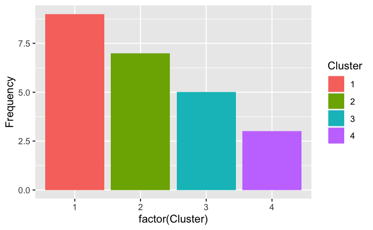

```r
tbl <- as.data.frame(table(sol$cluster))

colnames(tbl) <- c("Cluster", "Frequency")

ggplot(tbl, aes(factor(Cluster), Frequency, fill = Cluster)) +
  geom_col(position = 'dodge')
```

# Faces Dataset

- Only has binary attributes

## EDA

```r
faces <- read.csv("/Users/jasonchan/MSTAT/STAT8019_Marketing_Analytics/data/faces.csv")

head(exp_eg)
```

[output not shown]

```r
describe(faces, skew=F, ranges = F)
```

|  | vars | n | mean | sd | se |
| --- | --- | --- | --- | --- | --- |
| id | 1 | 12 | 6.50 | 3.61 | 1.04 |
| sex | 2 | 12 | 0.75 | 0.45 | 0.13 |
| glasses | 3 | 12 | 0.33 | 0.49 | 0.14 |
| moustache | 4 | 12 | 0.25 | 0.45 | 0.13 |
| smile | 5 | 12 | 0.50 | 0.52 | 0.15 |
| hat | 6 | 12 | 0.08 | 0.29 | 0.08 |

## Hierarchical Clustering

### Scaling

- Not needed as columns are already binary

### Proximity Matrix

```r
#Squared Euclidean distance = number of misatched
#number of  mismatched
dist<-dist(faces[,2:6],method="euclidean")^2
dist
```

```
   1 2 3 4 5 6 7 8 9 10 11
2  2
3  1 3
4  2 2 1
5  1 1 2 1
6  4 4 3 2 3
7  0 2 1 2 1 4
8  1 1 2 1 0 3 1
9  1 3 2 3 2 3 1 2
10 3 1 2 1 2 3 3 2 4
11 3 3 2 1 2 1 3 2 2  2
12 3 1 2 1 2 3 3 2 4  0  2
```

### Linkage

#### Complete Linkage

```r
#complete linkage
fit <- hclust(dist, method="com")
history<-cbind(fit$merge,fit$height)
history
```

```
      [,1] [,2] [,3]
 [1,]   -1   -7    0
 [2,]   -5   -8    0
 [3,]  -10  -12    0
 [4,]   -3    1    1
 [5,]   -2    2    1
 [6,]   -4    3    1
 [7,]   -6  -11    1
 [8,]   -9    4    2
 [9,]    5    6    2
[10,]    8    9    4
[11,]    7   10    4
```

### Distance Plot

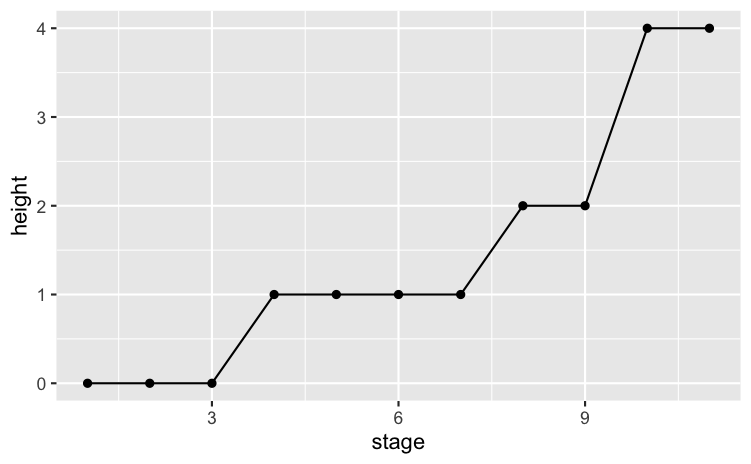

```r
#plot of distances
ggplot(mapping=aes(x=1:length(fit$height),y=fit$height))+
  geom_line()+
  geom_point()+
  labs(x="stage",y="height")
```

- Large jump from 3 to 2 clusters, hence, suggested 3 clusters

### Dendogram

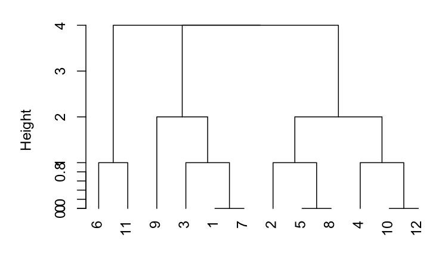

```r
#dengrogram
par(mar=c(2,5,1,1))
plot(fit,labels=faces$id,hang=-1,sub="",xlab="",main="")
axis(side = 2, at = seq(0, 0.8, 0.2))
```

### Cluster Solution

```r
#3-cluster solution
#cutreee() cut a tree into clusters
#tree= tree produced by hclust()
#k= number of clusters
sol <- data.frame(cluster=cutree(tree=fit, k=3),faces)
sol[order(sol[,1]),1:2]
```

|  | cluster | id |
| --- | --- | --- |
| 1 | 1 | 1 |
| 3 | 1 | 3 |
| 7 | 1 | 7 |
| 9 | 1 | 9 |
| 2 | 2 | 2 |
| 4 | 2 | 4 |
| 5 | 2 | 5 |
| 8 | 2 | 8 |
| 10 | 2 | 10 |
| 12 | 2 | 12 |

[output cut: 2 more lines]

```r
table(sol[,1])
```

```
1 2 3
4 6 2
```

### Prop Table

```r
#crosstab
for (i in 3:7) {
  print(colnames(sol)[i])
  t<-table(sol$cluster,sol[,i])
  print(prop.table(t,1))
}
```

```
[1] "sex"

      0   1
  1 0.0 1.0
  2 0.5 0.5
  3 0.0 1.0
[1] "glasses"

    0 1
  1 0 1
  2 1 0
  3 1 0
[1] "moustache"

       0    1
  1 0.75 0.25
  2 1.00 0.00
  3 0.00 1.00
[1] "smile"

       0    1
  1 0.25 0.75
  2 0.50 0.50
  3 1.00 0.00
[1] "hat"

      0   1
  1 1.0 0.0
  2 1.0 0.0
  3 0.5 0.5
```

## Cluster Chracteristics

```r
sol_table <- sol[, c(1, 3,4,5,6,7)]

sol_table %>%
  group_by(cluster) %>%
  summarise_at(vars(c('sex', 'glasses', 'moustache', 'smile', 'hat')), funs(mean(., na.rm=TRUE)))
```

| cluster | sex | glasses | moustache | smile | hat |
| --- | --- | --- | --- | --- | --- |
| 1 | 1.0 | 1 | 0.25 | 0.75 | 0.0 |
| 2 | 0.5 | 0 | 0.00 | 0.50 | 0.0 |
| 3 | 1.0 | 0 | 1.00 | 0.00 | 0.5 |

```r
sol_table %>%
  group_by(cluster) %>%
    summarise(Count = n())
```

| cluster | Count |
| --- | --- |
| 1 | 4 |
| 2 | 6 |
| 3 | 2 |

```r
NA
```

# U.S Utility Companies

## EDA

```r
public<-read.csv("/Users/jasonchan/MSTAT/STAT8019_Marketing_Analytics/data/public.csv", header = TRUE)

head(public)
```

|  | id | name | x1 | x2 | x3 | x4 | x5 | x6 | x7 | x8 |
| --- | --- | --- | --- | --- | --- | --- | --- | --- | --- | --- |
| 1 | 1 | Arizona | 1.06 | 9.2 | 151 | 54.4 | 1.6 | 9077 | 0.0 | 0.628 |
| 2 | 2 | Boston | 0.89 | 10.3 | 202 | 57.9 | 2.2 | 5088 | 25.3 | 1.555 |
| 3 | 3 | Central | 1.43 | 15.4 | 113 | 53.0 | 3.4 | 9212 | 0.0 | 1.058 |
| 4 | 4 | Common | 1.02 | 11.2 | 168 | 56.0 | 0.3 | 6423 | 34.3 | 0.700 |
| 5 | 5 | Consolid | 1.49 | 8.8 | 192 | 51.2 | 1.0 | 3300 | 15.6 | 2.044 |
| 6 | 6 | Florida | 1.32 | 13.5 | 111 | 60.0 | -2.2 | 11127 | 22.5 | 1.241 |

```r
describe(public, skew = F, ranges = F)
```

|  | vars | n | mean | sd | se |
| --- | --- | --- | --- | --- | --- |
| id | 1 | 22 | 11.50 | 6.49 | 1.38 |
| name* | 2 | 22 | 11.50 | 6.49 | 1.38 |
| x1 | 3 | 22 | 1.11 | 0.18 | 0.04 |
| x2 | 4 | 22 | 10.74 | 2.24 | 0.48 |
| x3 | 5 | 22 | 168.18 | 41.19 | 8.78 |
| x4 | 6 | 22 | 56.98 | 4.46 | 0.95 |
| x5 | 7 | 22 | 3.24 | 3.12 | 0.66 |
| x6 | 8 | 22 | 8914.05 | 3549.98 | 756.86 |
| x7 | 9 | 22 | 12.00 | 16.79 | 3.58 |
| x8 | 10 | 22 | 1.10 | 0.56 | 0.12 |

## K-Means Clustering

### Scaling

```r
public[,3:10]<-scale(public[,3:10]) ; head(public)
```

|  | id | name | x1 | x2 | x3 | x4 | x5 | x6 | x7 | x8 |
| --- | --- | --- | --- | --- | --- | --- | --- | --- | --- | --- |
| 1 | 1 | Arizona | -0.2931579 | -0.6846390 | -0.417122002 | -0.5777152 | -0.52622751 | 0.04590290 | -0.7146294 | -0.85367545 |
| 2 | 2 | Boston | -1.2145113 | -0.1944537 | 0.821002037 | 0.2068363 | -0.33381191 | -1.07776413 | 0.7920476 | 0.81329670 |
| 3 | 3 | Central | 1.7121407 | 2.0782236 | -1.339645796 | -0.8915357 | 0.05101929 | 0.08393124 | -0.7146294 | -0.08043055 |
| 4 | 4 | Common | -0.5099470 | 0.2066070 | -0.004413989 | -0.2190631 | -0.94312798 | -0.70170610 | 1.3280197 | -0.72420189 |
| 5 | 5 | Consolid | 2.0373243 | -0.8628882 | 0.578232617 | -1.2950193 | -0.71864311 | -1.58142837 | 0.2143888 | 1.69263800 |
| 6 | 6 | Florida | 1.1159709 | 1.2315399 | -1.388199680 | 0.6775672 | -1.74485965 | 0.62337028 | 0.6253007 | 0.24864810 |

### Pilot CLustering

```r
#k-means method, 5-cluster solution
set.seed(12345)
#kmeans() K-means clustering
#x= data set
#centers= number of clusters/centers of clusters
#algorithm= K-means algorithm
# MacQueen's method the traditional method
fit<-kmeans(x=public[3:10],centers=5,algorithm="MacQueen")
fit
```

```
K-means clustering with 5 clusters of sizes 4, 2, 3, 1, 12

Cluster means:
          x1          x2         x3          x4          x5
1  0.2352654  0.69679232 -0.9876301 -0.78506090 -0.30975996
2  0.6823928  0.83047922 -1.4731690  0.00509449 -1.72882501
3  0.4656037 -0.01620447  1.2984486  0.18442054  1.06654607
4 -1.9732730 -1.44219805  0.1169707 -1.22777208  1.04516655
5 -0.1441154 -0.24644302  0.2403785  0.31704709  0.03765709
          x6          x7         x8
1  0.1722415 -0.71462942 -0.4625574
2  0.9585831 -0.04466434 -0.2953207
3  1.0081607 -0.71462942 -0.9094210
4  2.4019698 -0.71462942 -0.6019213
5 -0.6693820  0.48386367  0.4809213

Clustering vector:
 [1] 1 5 1 5 5 2 5 3 3 5 4 5 5 1 5 3 5 1 2 5 5 5

Within cluster sum of squares by cluster:
[1] 10.440237  3.331318 10.308843  0.000000 71.970859
 (between_SS / total_SS =  42.8 %)

Available components:

[1] "cluster"      "centers"      "totss"        "withinss"
[5] "tot.withinss" "betweenss"    "size"         "iter"
[9] "ifault"
```

```r
#BSS/ESS, ratio r, higher is better
fit$betweenss/fit1$tot.withinss
```

```
[1] 1.060007
```

```r
#cluster solution
fit$cluster
```

```
 [1] 1 5 1 5 5 2 5 3 3 5 4 5 5 1 5 3 5 1 2 5 5 5
```

### Clustering with centriods from hclust of ward’s distance

```r
#rerun K-means with seeds from the Ward's method
dist<-dist(public[,3:10],method="euclidean")^2
fit2 <- hclust(dist, method="ward.D")
ward.sol<-cutree(fit2,k=5)
tb<-aggregate(public[,3:10],by=list(ward=ward.sol),FUN=mean)
#use the centers as seeds
fit1<-kmeans(x=public[3:10],centers=tb[,2:9],algorithm="MacQueen")
fit1
```

```
K-means clustering with 5 clusters of sizes 7, 6, 1, 5, 3

Cluster means:
          x1         x2          x3         x4          x5         x6
1  0.5043161  0.7795509 -0.98589607 -0.3375463 -0.48957692  0.3518600
2 -0.2118620  0.2437423  0.31927857 -0.2638946  0.08308855 -0.5145222
3  2.0373243 -0.8628882  0.57823262 -1.2950193 -0.71864311 -1.5814284
4 -0.4991075 -0.7113763  0.07812761  1.3365904  0.13439938 -0.6728046
5 -0.6002757 -0.8331800  1.33891013 -0.4805802  0.99171778  1.8565214
          x7         x8
1 -0.5232108 -0.4105368
2  1.4362066 -0.3606569
3  0.2143888  1.6926380
4 -0.6050529  1.2484717
5 -0.7146294 -0.9657660

Clustering vector:
 [1] 1 2 1 2 3 1 4 5 1 2 5 4 2 1 4 5 4 1 1 2 4 2

Within cluster sum of squares by cluster:
[1] 26.507769 14.922842  0.000000 16.911559  9.533522
 (between_SS / total_SS =  59.6 %)

Available components:

[1] "cluster"      "centers"      "totss"        "withinss"
[5] "tot.withinss" "betweenss"    "size"         "iter"
[9] "ifault"
```

```r
#BSS/ESS, ratio r, higher is better
fit1$betweenss/fit1$tot.withinss
```

```
[1] 1.475113
```

```r
#cluster solution
fit1$cluster
```

```
 [1] 1 2 1 2 3 1 4 5 1 2 5 4 2 1 4 5 4 1 1 2 4 2
```

- Higher r ratio for using hclust centers

## Visualizing clusters

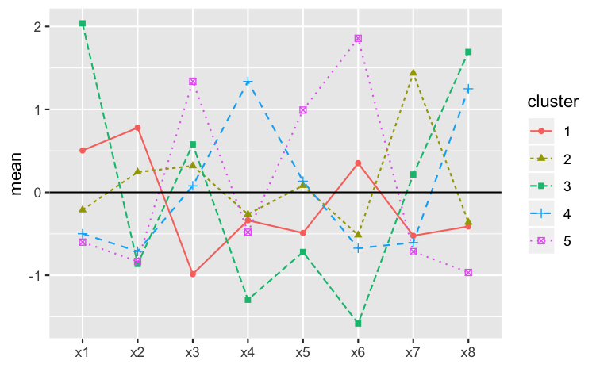

## Cluster Count

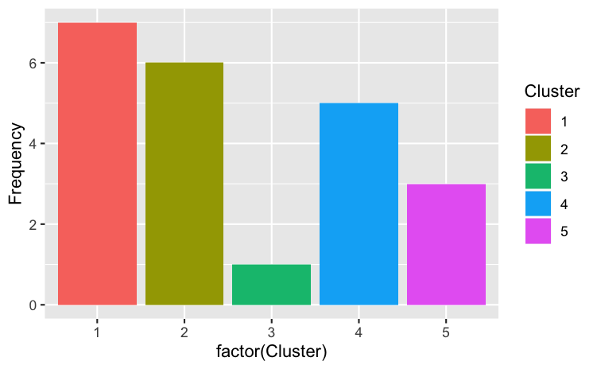

### Cluster Insights

Utility companies tend to group/competitive according to geographical location

- C4: East and West but near coasts
- C2: Eastern + Central
- C1: Southern
- C5: North-West
- 5 (Consolidated Edison Co.) stands by itself

Firms with similar locations (or types of locations) cluster

- Firms in the same area to use, basically, the same type of fuel(s) for power plants and face common markets
- Consequently, type of generation, costs, growth rates, and so forth should be relatively homogeneous among these firms.

## Algorithm Comparison

```r
#combine data
sol<-cbind(kmeans=fit1$cluster,ward=ward.sol,kmeans_initial=fit$cluster,public)
sol[order(sol[1]),c("name","id", "kmeans","ward", "kmeans_initial")]
```

|  | name | id | kmeans | ward | kmeans_initial |
| --- | --- | --- | --- | --- | --- |
| 1 | Arizona | 1 | 1 | 1 | 1 |
| 3 | Central | 3 | 1 | 1 | 1 |
| 6 | Florida | 6 | 1 | 1 | 2 |
| 9 | Kentucky | 9 | 1 | 1 | 3 |
| 14 | Oklahoma | 14 | 1 | 1 | 1 |
| 18 | Southern | 18 | 1 | 1 | 1 |
| 19 | Texas | 19 | 1 | 1 | 2 |
| 2 | Boston | 2 | 2 | 2 | 5 |
| 4 | Common | 4 | 2 | 2 | 5 |
| 10 | Madison | 10 | 2 | 2 | 5 |

[output cut: 12 more lines]

- Using the centers of the ward in K means will give us back the same clustering results in this case.
- Using the centers of ward in K means is indirectly using the same set seed